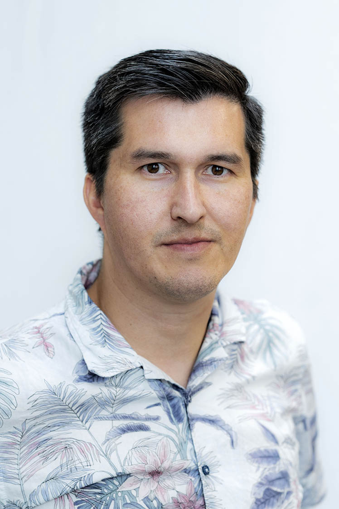

# About me

I am from Chile 🇨🇱, where I grew up as an artisanal fisherman, catching Southern hake and other delicious fish.  
I started this trade at the tender age of 12, spending my summer and winter school holidays at sea.  
Even now, those early days still bring a lump to my throat — a source of great pride and cherished memories.

Today, I’m thrilled to be back at Radboud University, continuing my research as a postdoctoral fellow.

My research primarily focuses on *macrophysiology*, complemented by elements of experimental *ecophysiology*, though this plays a smaller role in my work nowadays. These approaches enable me to uncover how animals thrive and adapt to ever-changing environmental conditions, across space and time.

## Education

PhD in Science | Radboud University, Netherlands 🇳🇱 | March 2017 –December 2022  
Aquaculture Engineer | Universidad Austral de Chile, Chile 🇨🇱 | March 2005 – February 2011

## Experience

Postdoctoral Researcher | Radboud University, Netherlands 🇳🇱 | January 2025 – Present  
Postdoctoral Researcher | Alfred Wegener Institute, Germany 🇩🇪 | January 2022 – December 2024  
Research Assistant | Centro i-mar, Universidad de Los Lagos, Chile 🇨🇱 | 2014 – 2017